# Background resource extension

## Load libraries

Mizer 2.0.1 updated at 23/05/2020 or later version is needed to use the background extension.

First and best option: download the most updated version of the package directly from GitHub using devtools::install_github(“sizespectrum/mizer”)

```r
# devtools::install_github("sizespectrum/mizer") # run only once
library(mizer)
library(viridisLite)
library(viridis)
library(ggplot2)
library(ggrepel)
library(tidyverse)
library(mizerExperimental)
library(mizerHowTo)
source("utility.R")
```

## Set up multispecies model

my parameters

```r
# laoding calibrated simulation
sim <- readRDS("sim_optim3_KP.RDS")
params <- sim@params
```

Need to edit resource interaction matrix? Default is 1

```r
#KP: changed the interaction resource to 1? I think I need to change numbers based on who is eating it?
params@species_params$interaction_resource <-c(1,1,1,1,1)
# sim_loop@params@species_params$interaction_resource

params <- setParams(sim@params)

# create the param object
# note: some def values are different from old mizer (e.g. kappa)
```

## Add a second background spectrum to the Param object

To create a new component, the background resource spectrum, you need to use setComponent(). See **extension.r** in Mizer package for a detailed description of this function and its arguments

In brief, setComponent (params, component, initial_value, dynamics_fun, encounter_fun, mort_fun, component_params)

params = A MizerParams object  
component = Name of the component  
initial_value = Initial value of the component  
dynamics_fun = Name of function to calculate value at the next time step  
encounter_fun = Name of function to calculate contribution to encounter rate. Optional  
mort_fun = Name of function to calculate contribution to the mortality rate. Optional  
component_params = Named list of parameters needed by the component functions. Optional

### How it works

We need to specify our own functions (dynamics, encounter and mortality) for each background resource component we’d like to add.

This can be done in 6 steps:

1. Specify the background dynamics function  
   dynamics_fun = background_bb_semichemostat, which is the same as resource_semichemostat() in **resource_dynamics.r**, but uses newly defined rr_pp (here called rate) and cc_pp (here called capacity), and it includes the mortality function

```r
background_invertebrate_semichemostat <- function(params, n_other, rates, dt, ...) {

    # locate where (which params slot) the parameters needed for this function are stored
    component <- "background_invertebrate"
    c <- params@other_params[[component]]

    # name of interaction parameter for this component in species_params
    interaction_component <- paste0("interaction_", component)
    interaction <- params@species_params[[interaction_component]]

    # Step 3: specify the background mortality function
    mort <- as.vector(interaction  %*% rates$pred_rate)

    # specify the background dynamics function. This is the same as resource_semichemostat() - see above
    tmp <- c$rate * c$capacity / (c$rate + mort)
    return(tmp - (tmp - n_other[[component]]) * exp(-(c$rate + mort) * dt))
}
```

2. Specify the encounter function  
   encounter_fun = background_bb_encounter, which is same as mizerEncounter() in **project_methods.r**, but now n_pp is the sum of the 2 background spectra

```r
background_invertebrate_encounter <- function(params, n, n_pp, n_other, ...) {
    idx_sp <- (length(params@w_full) - length(params@w) + 1):length(params@w_full)
    prey <- #outer(params@species_params$interaction_resource, n_pp) +
        outer(params@species_params$interaction_background_invertebrate, n_other$background_invertebrate)
    # prey[, idx_sp] <- prey[, idx_sp] + params@interaction %*% n
    prey <- sweep(prey, 2, params@w_full * params@dw_full, "*")
    avail_energy <- Re(base::t(mvfft(base::t(params@ft_pred_kernel_e) *
                                         mvfft(base::t(prey)),
                                     inverse = TRUE))) / length(params@w_full)
    avail_energy <- avail_energy[, idx_sp, drop = FALSE]
    avail_energy[avail_energy < 1e-18] <- 0

    params@search_vol * avail_energy
}
```

3. Specify the mortality function  
   mort_fun = mort, which is the same as mizerResourceMort() in **project_methods.r**, but uses different interaction values (interaction_resource) and pred_rate. Mortality in this case is specified as part of background_bb_semichemostat(). For any other extensions you’d need something like:

```r
# background_bb_mortality<-...mizerMortality()...
```

4. Set up parameters  
   Calcualate rate and capacity used in background_bb_semichemostat() and given kappa, lambda etc. for the bb spectrum

```r
## KP: These were the values from Annabelle, not sure if they need changing
kappa <- 0.001
lambda <- 2.05
r_pp <- 10
n <- 0.666
w_pp_cutoff <- 100
rate <- r_pp * params@w_full^(n - 1)
capacity <- kappa * params@w_full^(-lambda)
capacity[params@w_full > w_pp_cutoff] <- 0
w_pp_min <- 1e-6 # set minimum size of new resource
capacity[params@w_full > w_pp_cutoff] <- 0

# Set interaction species-background_invertebrate - i.e. proportion available to each species.
# this new species param column needs to be named as "interaction_" + component name
params@species_params$interaction_background_invertebrate <- c(1,1,1,1,1)

#params@species_params
## so now we have an interactions for all species on both resources.
```

5. Add components  
   Add the background bb resource spectrum to the params object using setComponent()

```r
params2 <- setComponent(params = params, component = "background_invertebrate",
                        initial_value = params@initial_n_pp,
                        dynamics_fun =  "background_invertebrate_semichemostat",
                        encounter_fun = "background_invertebrate_encounter",
                        component_params = list(rate = rate,
                                                capacity = capacity))
```

6. Update the encounter function

```r
# params2 <- setRateFunction(params2, "Encounter", "background_bb_encounter")
```

7. Update the mortality function  
   Mortality in this case is specified as part of background_bb_semichemostat() so you don’t need to update this function. For any other extensions you’d need to run the line below:

```r
# params2<-setRateFunction(params2, "Mortality", "background_benthic_mortality")
```

8. Update the colors in the params object

If you want to plot something, it needs to appear in `params@linecolour` and `params@linetype` Use the same names as in `setComponent()`

```r
moreColors <- c(params2@linecolour, "tomato") # add as many colors as necessary
names(moreColors)[(length(params2@linecolour)+1):length(moreColors)] <- c("background_invertebrate") # names for the colors
params2@linecolour <- moreColors
moreTypes <- c(params2@linetype, rep("dashed",1)) # add the types, need to be one type per new background | can be the same types
names(moreTypes) <- names(moreColors)
params2@linetype <- moreTypes
```

### Run project() using the newly defined Param object

Params2 now includes a pp and a bb (INVERTEBRATE) background spectrum, let’s check if it works

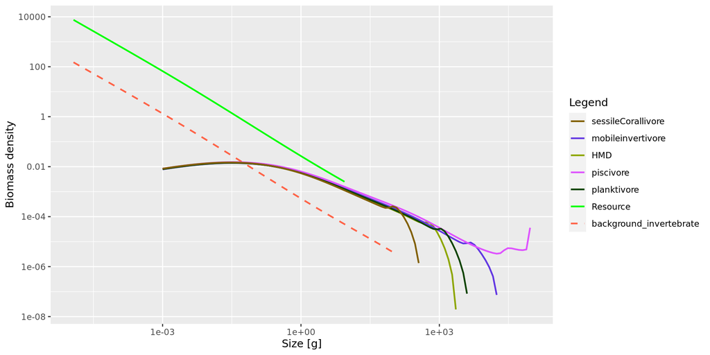

```r
params2<-setParams(params2)

sim2 <- project(params2, t_max = 100, effort = 0)
plotSpectra2(sim2)
```

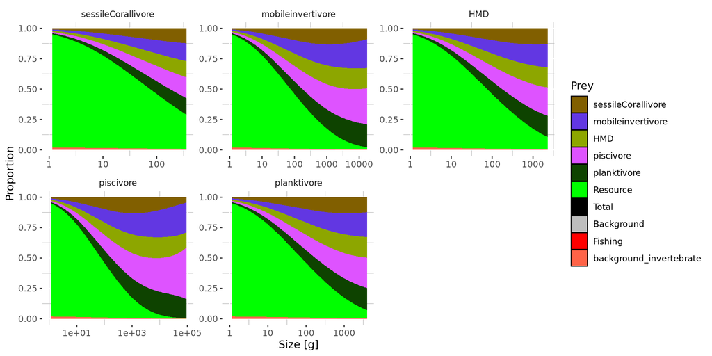

```r
plotDiet2(sim2)
```

# Adding a third background

```r
# step 1
background_pelagic_semichemostat <- function(params, n_other, rates, dt, ...) {

    # locate where (which params slot) the parameters needed for this function are stored
    component <- "background_pelagic"
    c <- params@other_params[[component]]

    # name of interaction parameter for this component in species_params
    interaction_component <- paste0("interaction_", component)
    interaction <- params@species_params[[interaction_component]]

    # Step 3: specify the background mortality function
    mort <- as.vector(interaction  %*% rates$pred_rate)

    # specify the background dynamics function. This is the same as resource_semichemostat() - see above
    tmp <- c$rate * c$capacity / (c$rate + mort)
    return(tmp - (tmp - n_other[[component]]) * exp(-(c$rate + mort) * dt))
}


# step2


background_pelagic_encounter <- function(params, n, n_pp, n_other, ...) {
    idx_sp <- (length(params@w_full) - length(params@w) + 1):length(params@w_full)
    prey <- #outer(params@species_params$interaction_resource, n_pp) +
        outer(params@species_params$interaction_background_pelagic, n_other$background_pelagic)
    # prey[, idx_sp] <- prey[, idx_sp] + params@interaction %*% n
    prey <- sweep(prey, 2, params@w_full * params@dw_full, "*")
    avail_energy <- Re(base::t(mvfft(base::t(params@ft_pred_kernel_e) *
                                         mvfft(base::t(prey)),
                                     inverse = TRUE))) / length(params@w_full)
    avail_energy <- avail_energy[, idx_sp, drop = FALSE]
    avail_energy[avail_energy < 1e-18] <- 0

    params@search_vol * avail_energy
}


# step4

## KP: These were the values from Annabelle, not sure if they need changing
kappa <- 0.001
lambda <- 2.05
r_pp <- 10
n <- 0.666
w_pp_cutoff <- 100
rate <- r_pp * params@w_full^(n - 1)
capacity <- kappa * params@w_full^(-lambda)
capacity[params@w_full > w_pp_cutoff] <- 0
w_pp_min <- 1e-6 # set minimum size of new resource
capacity[params@w_full > w_pp_cutoff] <- 0

# Set interaction species-background_invertebrate - i.e. proportion available to each species.
# this new species param column needs to be named as "interaction_" + component name
params2@species_params$interaction_background_pelagic <- c(0,0,0,0,1)

#params@species_params
## so now we have an interactions for all species on both resources.

# step5

params3 <- setComponent(params = params2, component = "background_pelagic",
                        initial_value = params@initial_n_pp,
                        dynamics_fun =  "background_pelagic_semichemostat",
                        encounter_fun = "background_pelagic_encounter",
                        component_params = list(rate = rate,
                                                capacity = capacity))

#step 8

moreColors <- c(params3@linecolour, "aquamarine3") # add as many colors as necessary
names(moreColors)[(length(params3@linecolour)+1):length(moreColors)] <- c("background_pelagic") # names for the colors
params3@linecolour <- moreColors
moreTypes <- c(params3@linetype, rep("dashed",1)) # add the types, need to be one type per new background | can be the same types
names(moreTypes) <- names(moreColors)
params3@linetype <- moreTypes
```

## Run project

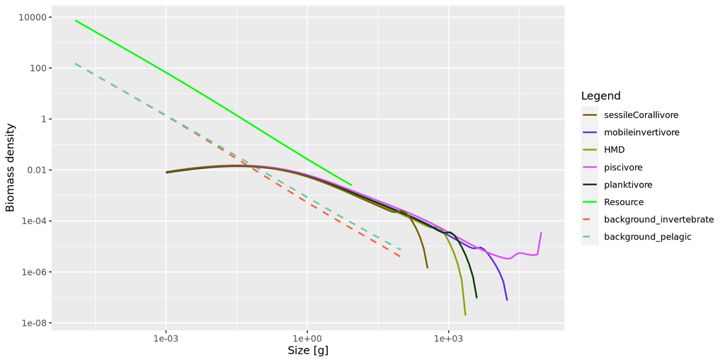

```r
params3<-setParams(params3)

sim3 <- project(params3, t_max = 100, effort = 0)
plotSpectra2(sim3)
```

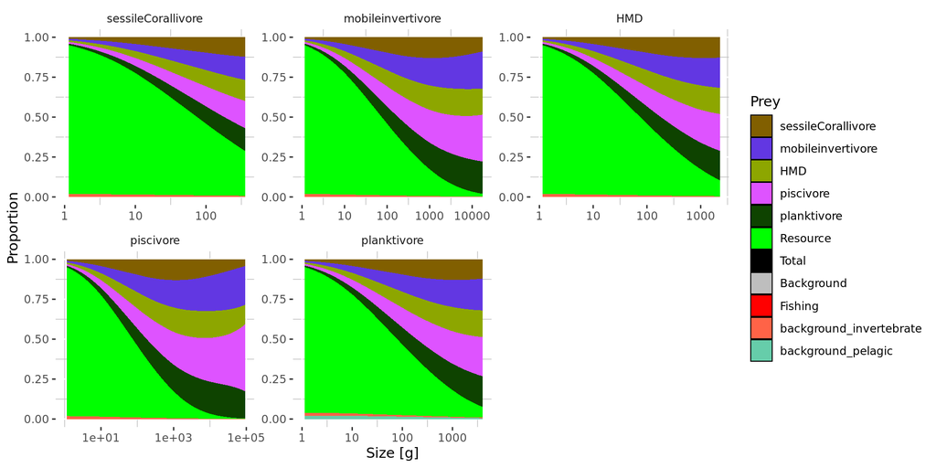

```r
plotDiet2(sim3)
```